# R Notebook

# Normalize the data

After removing unwanted cells from the dataset, we can normalize the data. By default, Seurat employs a global-scaling normalization method “LogNormalize” that normalizes the feature expression measurements for each cell by the total expression, multiplies this by a scale factor (10,000 by default), and log-transforms the result. Normalized values are stored in innateTcell[[“RNA”]]@data.

```r
innateTcell <- NormalizeData(innateTcell, normalization.method = "LogNormalize", scale.factor = 10000)
```

```
Normalizing layer: counts
```

# Identification of highly variable features (feature selection)

Calculate a subset of features that exhibit high cell-to-cell variation in the dataset (i.e, they are highly expressed in some cells, and lowly expressed in others). Focusing on these genes in downstream analysis helps to highlight biological signal in single-cell datasets.

Seurat v3 improves on previous versions by directly modeling the mean-variance relationship inherent in single-cell data, and is implemented in the FindVariableFeatures() function. By default, Seurat returns 2,000 features per dataset that can be used in downstream analysis, like PCA.

```r
innateTcell <- FindVariableFeatures(innateTcell, selection.method = "vst", nfeatures = 2000)
```

```
Finding variable features for layer counts
```

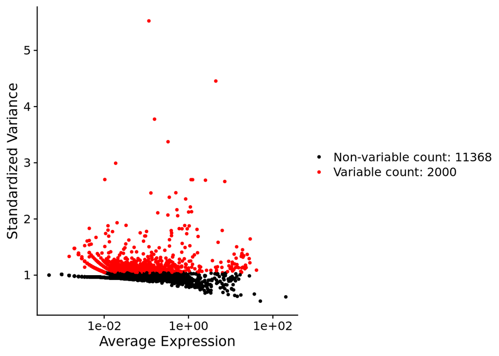

```r
# Identify the 10 most highly variable genes
top10 <- head(VariableFeatures(innateTcell), 10)

# plot variable features with and without labels
plot1 <- VariableFeaturePlot(innateTcell)
plot1
```

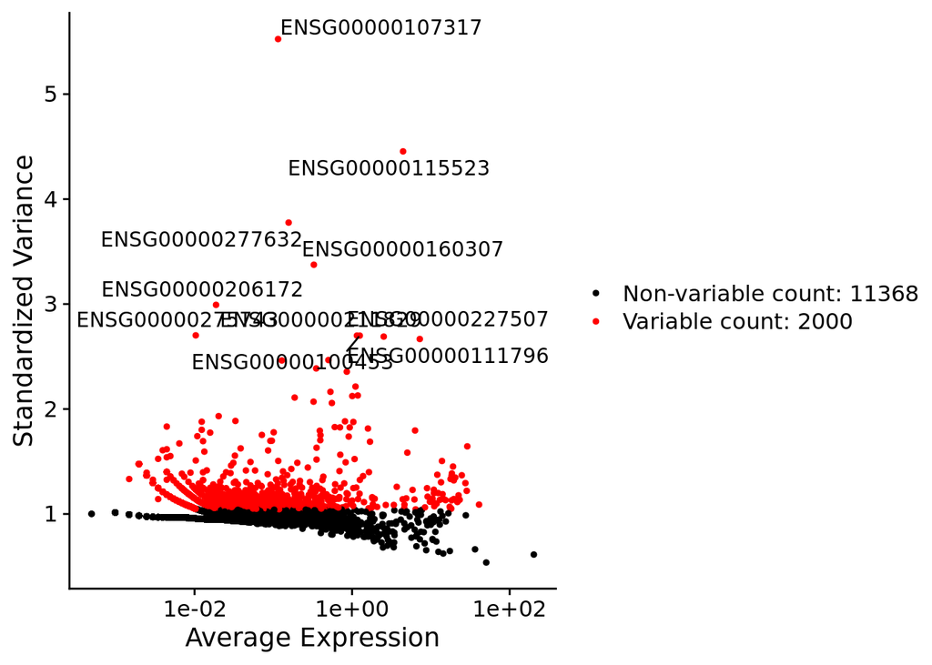

```r
plot2 <- LabelPoints(plot = plot1, points = top10, xnudge=0, ynudge=0, repel = TRUE) #When using repel, set xnudge and ynudge to 0 for optimal results
plot2
```

# Scaling the data

Next, apply a linear transformation (‘scaling’) that is a standard pre-processing step prior to dimensional reduction techniques like PCA. The ScaleData() function:

- Shifts the expression of each gene, so that the mean expression across cells is 0
- Scales the expression of each gene, so that the variance across cells is 1
  - This step gives equal weight in downstream analyses, so that highly-expressed genes do not dominate
- The results of this are stored in innateTcell[[“RNA”]]@scale.data

```r
all.genes <- rownames(innateTcell)
innateTcell <- ScaleData(innateTcell, features = all.genes)
```

# Perform linear dimensional reduction

Next we perform PCA on the scaled data. By default, only the previously determined variable features are used as input, but can be defined using features argument if you wish to choose a different subset.

```r
innateTcell <- RunPCA(innateTcell, features = VariableFeatures(object = innateTcell))
```

```
PC_ 1
Positive:  ENSG00000109475, ENSG00000167526, ENSG00000198918, ENSG00000112306, ENSG00000144713, ENSG00000177954, ENSG00000156508, ENSG00000122026, ENSG00000142937, ENSG00000213741
       ENSG00000137154, ENSG00000142541, ENSG00000134419, ENSG00000142676, ENSG00000147403, ENSG00000231500, ENSG00000233927, ENSG00000145425, ENSG00000143947, ENSG00000177600
       ENSG00000118181, ENSG00000198034, ENSG00000163682, ENSG00000105640, ENSG00000130255, ENSG00000186468, ENSG00000164587, ENSG00000182899, ENSG00000197958, ENSG00000140988
Negative:  ENSG00000105374, ENSG00000100453, ENSG00000134539, ENSG00000115523, ENSG00000137441, ENSG00000077984, ENSG00000150045, ENSG00000203747, ENSG00000011600, ENSG00000100450
       ENSG00000275302, ENSG00000180644, ENSG00000122862, ENSG00000159674, ENSG00000158869, ENSG00000172543, ENSG00000169554, ENSG00000075624, ENSG00000145649, ENSG00000271503
       ENSG00000169583, ENSG00000171476, ENSG00000211829, ENSG00000160255, ENSG00000168329, ENSG00000145287, ENSG00000163453, ENSG00000142634, ENSG00000115956, ENSG00000181036
PC_ 2
Positive:  ENSG00000111796, ENSG00000113088, ENSG00000008517, ENSG00000271503, ENSG00000139187, ENSG00000196154, ENSG00000227191, ENSG00000235576, ENSG00000144290, ENSG00000145649
       ENSG00000145220, ENSG00000174946, ENSG00000112419, ENSG00000168685, ENSG00000172215, ENSG00000105374, ENSG00000245105, ENSG00000204482, ENSG00000120129, ENSG00000102245
       ENSG00000112486, ENSG00000169442, ENSG00000135046, ENSG00000204475, ENSG00000122417, ENSG00000277734, ENSG00000057657, ENSG00000160791, ENSG00000197635, ENSG00000158050
Negative:  ENSG00000126353, ENSG00000172005, ENSG00000188404, ENSG00000138795, ENSG00000158869, ENSG00000204472, ENSG00000164300, ENSG00000072110, ENSG00000173114, ENSG00000166681
       ENSG00000189283, ENSG00000182463, ENSG00000082074, ENSG00000143110, ENSG00000115687, ENSG00000256039, ENSG00000114861, ENSG00000100100, ENSG00000134352, ENSG00000159674
       ENSG00000036448, ENSG00000166405, ENSG00000163453, ENSG00000186854, ENSG00000100453, ENSG00000158525, ENSG00000102760, ENSG00000117318, ENSG00000148908, ENSG00000147457
PC_ 3
Positive:  ENSG00000158869, ENSG00000111796, ENSG00000163453, ENSG00000221869, ENSG00000036448, ENSG00000074966, ENSG00000196139, ENSG00000167664, ENSG00000144290, ENSG00000175040
       ENSG00000168209, ENSG00000227507, ENSG00000169583, ENSG00000132965, ENSG00000150045, ENSG00000135077, ENSG00000196684, ENSG00000168995, ENSG00000159674, ENSG00000198574
       ENSG00000204475, ENSG00000064393, ENSG00000011600, ENSG00000142089, ENSG00000229807, ENSG00000160593, ENSG00000170298, ENSG00000100385, ENSG00000204482, ENSG00000171604
Negative:  ENSG00000160654, ENSG00000223865, ENSG00000169442, ENSG00000100450, ENSG00000196126, ENSG00000069493, ENSG00000231389, ENSG00000008517, ENSG00000181847, ENSG00000205809
       ENSG00000211829, ENSG00000129824, ENSG00000172116, ENSG00000271503, ENSG00000198502, ENSG00000211689, ENSG00000176083, ENSG00000197747, ENSG00000229474, ENSG00000196735
       ENSG00000222041, ENSG00000181036, ENSG00000213145, ENSG00000177954, ENSG00000150347, ENSG00000116824, ENSG00000159335, ENSG00000150093, ENSG00000066294, ENSG00000169554
PC_ 4
Positive:  ENSG00000129824, ENSG00000160307, ENSG00000026025, ENSG00000176083, ENSG00000169442, ENSG00000023445, ENSG00000100097, ENSG00000227507, ENSG00000196154, ENSG00000107581
       ENSG00000184009, ENSG00000150093, ENSG00000244879, ENSG00000036448, ENSG00000167522, ENSG00000167460, ENSG00000164022, ENSG00000088986, ENSG00000137078, ENSG00000067646
       ENSG00000197448, ENSG00000163453, ENSG00000054654, ENSG00000160221, ENSG00000107317, ENSG00000137441, ENSG00000165272, ENSG00000277972, ENSG00000127914, ENSG00000245532
Negative:  ENSG00000187118, ENSG00000211829, ENSG00000158050, ENSG00000143184, ENSG00000181847, ENSG00000134539, ENSG00000229807, ENSG00000211689, ENSG00000134545, ENSG00000205809
       ENSG00000271503, ENSG00000233927, ENSG00000143185, ENSG00000011600, ENSG00000142089, ENSG00000174255, ENSG00000145220, ENSG00000122026, ENSG00000213741, ENSG00000177954
       ENSG00000150045, ENSG00000134419, ENSG00000198034, ENSG00000137880, ENSG00000177600, ENSG00000125148, ENSG00000272211, ENSG00000109943, ENSG00000117281, ENSG00000277632
PC_ 5
Positive:  ENSG00000185201, ENSG00000143184, ENSG00000143185, ENSG00000184009, ENSG00000205809, ENSG00000187118, ENSG00000211829, ENSG00000211772, ENSG00000144426, ENSG00000125148
       ENSG00000137818, ENSG00000197958, ENSG00000135404, ENSG00000007264, ENSG00000103490, ENSG00000196126, ENSG00000229807, ENSG00000156508, ENSG00000133112, ENSG00000122406
       ENSG00000142089, ENSG00000117281, ENSG00000196735, ENSG00000198034, ENSG00000116251, ENSG00000019582, ENSG00000105372, ENSG00000011600, ENSG00000075624, ENSG00000140988
Negative:  ENSG00000176083, ENSG00000143443, ENSG00000086062, ENSG00000160307, ENSG00000197622, ENSG00000129824, ENSG00000149480, ENSG00000069493, ENSG00000266378, ENSG00000137441
       ENSG00000277734, ENSG00000168036, ENSG00000121966, ENSG00000147459, ENSG00000169045, ENSG00000013725, ENSG00000057657, ENSG00000086619, ENSG00000137078, ENSG00000169814
       ENSG00000160221, ENSG00000169442, ENSG00000185905, ENSG00000184293, ENSG00000162383, ENSG00000134198, ENSG00000169508, ENSG00000211751, ENSG00000164221, ENSG00000069667
```

```r
# Examine and visualize PCA results a few different ways
print(innateTcell[["pca"]], dims = 1:5, nfeatures = 5)
```

```
PC_ 1
Positive:  ENSG00000109475, ENSG00000167526, ENSG00000198918, ENSG00000112306, ENSG00000144713
Negative:  ENSG00000105374, ENSG00000100453, ENSG00000134539, ENSG00000115523, ENSG00000137441
PC_ 2
Positive:  ENSG00000111796, ENSG00000113088, ENSG00000008517, ENSG00000271503, ENSG00000139187
Negative:  ENSG00000126353, ENSG00000172005, ENSG00000188404, ENSG00000138795, ENSG00000158869
PC_ 3
Positive:  ENSG00000158869, ENSG00000111796, ENSG00000163453, ENSG00000221869, ENSG00000036448
Negative:  ENSG00000160654, ENSG00000223865, ENSG00000169442, ENSG00000100450, ENSG00000196126
PC_ 4
Positive:  ENSG00000129824, ENSG00000160307, ENSG00000026025, ENSG00000176083, ENSG00000169442
Negative:  ENSG00000187118, ENSG00000211829, ENSG00000158050, ENSG00000143184, ENSG00000181847
PC_ 5
Positive:  ENSG00000185201, ENSG00000143184, ENSG00000143185, ENSG00000184009, ENSG00000205809
Negative:  ENSG00000176083, ENSG00000143443, ENSG00000086062, ENSG00000160307, ENSG00000197622
```

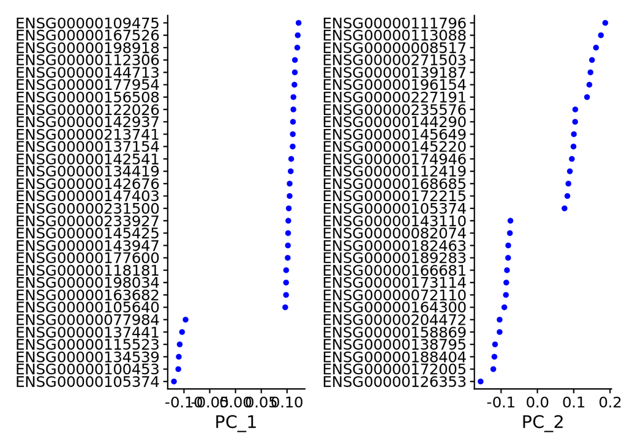

```r
VizDimLoadings(innateTcell, dims = 1:2, reduction = "pca")
```

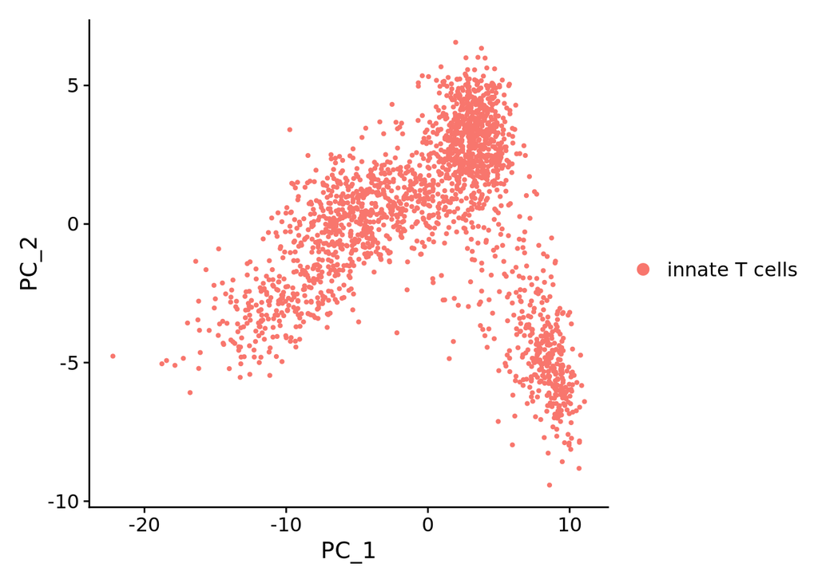

```r
DimPlot(innateTcell, reduction = "pca")
```

# Determine the ‘dimensionality’ of the dataset

To overcome the extensive technical noise in any single feature for scRNA-seq data, Seurat clusters cells based on their PCA scores, with each PC essentially representing a ‘metafeature’ that combines information across a correlated feature set. The top principal components therefore represent a robust compression of the dataset. However, how many components should we choose to include?

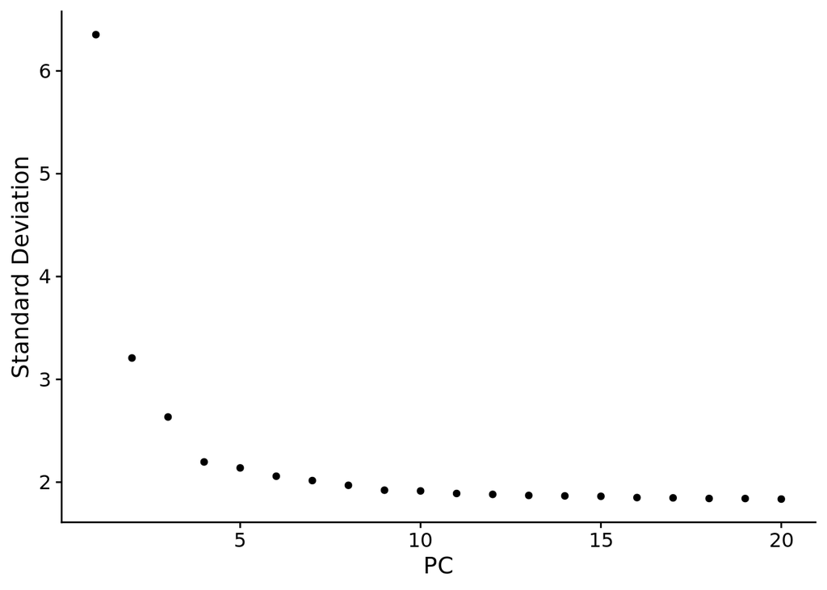

```r
ElbowPlot(innateTcell)
```

# Cluster the cells

To cluster the cells, apply modularity optimization techniques to iteratively group cells together, with the goal of optimizing the standard modularity function. The FindClusters() function implements this procedure, and contains a resolution parameter that sets the ‘granularity’ of the downstream clustering, with increased values leading to a greater number of clusters. Setting this parameter between 0.4-1.2 typically returns good results for single-cell datasets of around 3K cells. Optimal resolution often increases for larger datasets. The clusters can be found using the Idents() function.

```r
innateTcell <- FindNeighbors(innateTcell, dims = 1:10)
innateTcell <- FindClusters(innateTcell, resolution = 0.5)
```

```
Modularity Optimizer version 1.3.0 by Ludo Waltman and Nees Jan van Eck

Number of nodes: 2027
Number of edges: 75885

Running Louvain algorithm...
Maximum modularity in 10 random starts: 0.8353
Number of communities: 4
Elapsed time: 0 seconds
```

# Run non-linear dimensional reduction (UMAP/tSNE)

```r
# If you haven't installed UMAP, you can do so via reticulate::py_install(packages =
# 'umap-learn')
innateTcell <- RunUMAP(innateTcell, dims = 1:5)
```

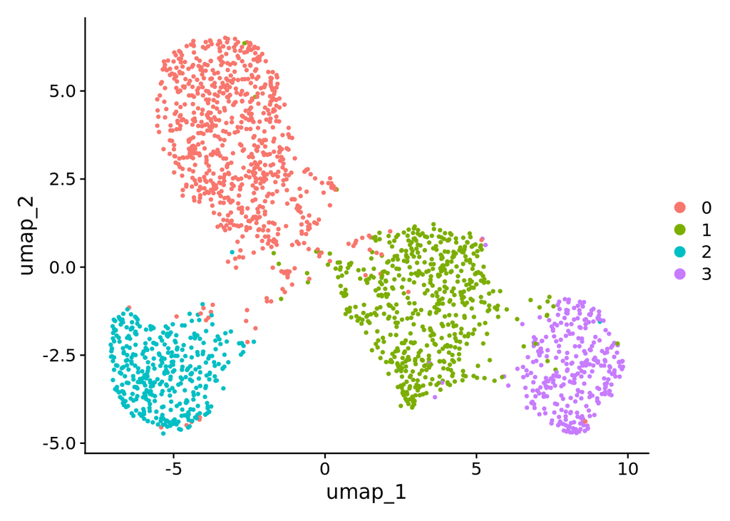

```r
# note that you can set `label = TRUE` or use the LabelClusters function to help label
# individual clusters
DimPlot(innateTcell, reduction = "umap")
```

You can save the object at this point so that it can easily be loaded back in without having to rerun the computationally intensive steps performed above, or easily shared with collaborators.

```r
saveRDS(innateTcell, file = "../results/seurat_intermediate.rds")
```

# Finding differentially expressed features (cluster biomarkers)

Seurat can help you find markers that define clusters via differential expression. By default, it identifies positive and negative markers of a single cluster (specified in ident.1), compared to all other cells. FindAllMarkers() automates this process for all clusters, but you can also test groups of clusters vs. each other, or against all cells.

The min.pct argument requires a feature to be detected at a minimum percentage in either of the two groups of cells, and the thresh.test argument requires a feature to be differentially expressed (on average) by some amount between the two groups.

```r
# find markers for every cluster compared to all remaining cells, report only the positive
# ones
innateTcell.markers <- FindAllMarkers(innateTcell, only.pos = TRUE, min.pct = 0.25, logfc.threshold = 0.25)
innateTcell.markers %>%
    group_by(cluster) %>%
    slice_max(n = 2, order_by = avg_log2FC)
```

| p_val | avg_log2FC | pct.1 | pct.2 | p_val_adj | cluster | gene |
| --- | --- | --- | --- | --- | --- | --- |
| 1.127702e-164 | 2.492754 | 0.789 | 0.188 | 1.507512e-160 | 0 | ENSG00000113088 |
| 1.991031e-46 | 2.253741 | 0.300 | 0.061 | 2.661610e-42 | 0 | ENSG00000112419 |
| 1.504176e-141 | 2.412423 | 0.819 | 0.292 | 2.010783e-137 | 1 | ENSG00000100450 |
| 4.521012e-37 | 2.180651 | 0.300 | 0.086 | 6.043689e-33 | 1 | ENSG00000231389 |
| 2.146450e-122 | 5.439911 | 0.362 | 0.009 | 2.869374e-118 | 2 | ENSG00000172005 |
| 9.891768e-78 | 4.233049 | 0.289 | 0.019 | 1.322331e-73 | 2 | ENSG00000204472 |
| 3.510642e-103 | 6.462582 | 0.298 | 0.006 | 4.693026e-99 | 3 | ENSG00000163453 |
| 6.587622e-230 | 5.240589 | 0.789 | 0.066 | 8.806333e-226 | 3 | ENSG00000158869 |

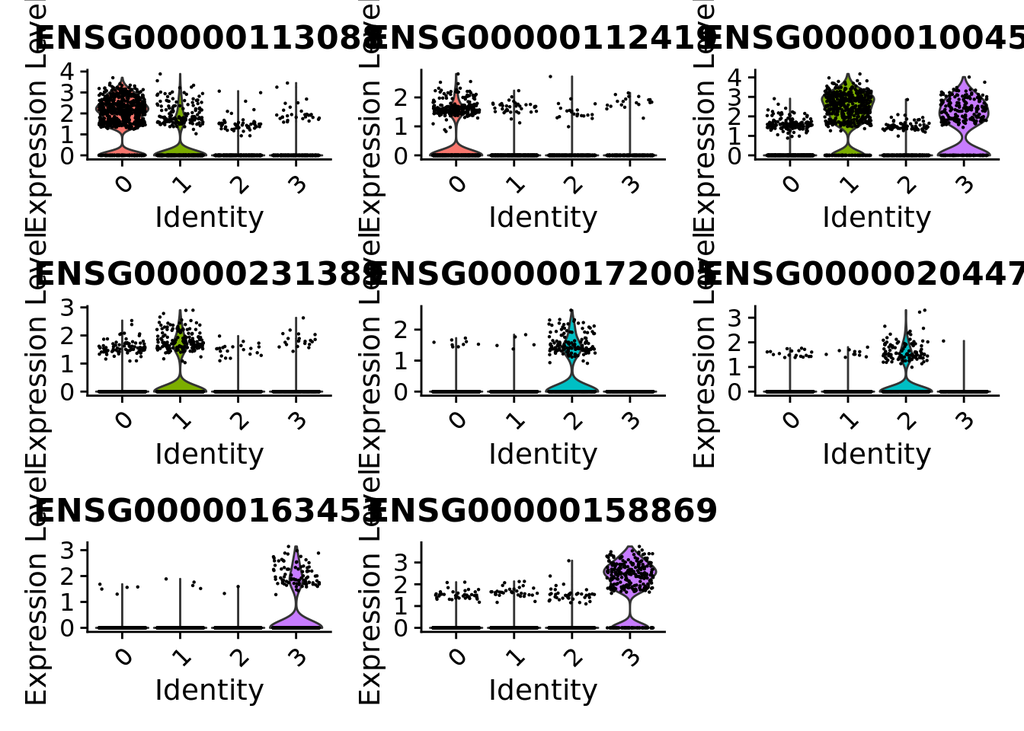

```r
# Visualize 8 differentially expressed genes
VlnPlot(innateTcell, features = c("ENSG00000113088","ENSG00000112419","ENSG00000100450","ENSG00000231389",
"ENSG00000172005","ENSG00000204472","ENSG00000163453","ENSG00000158869"))
```

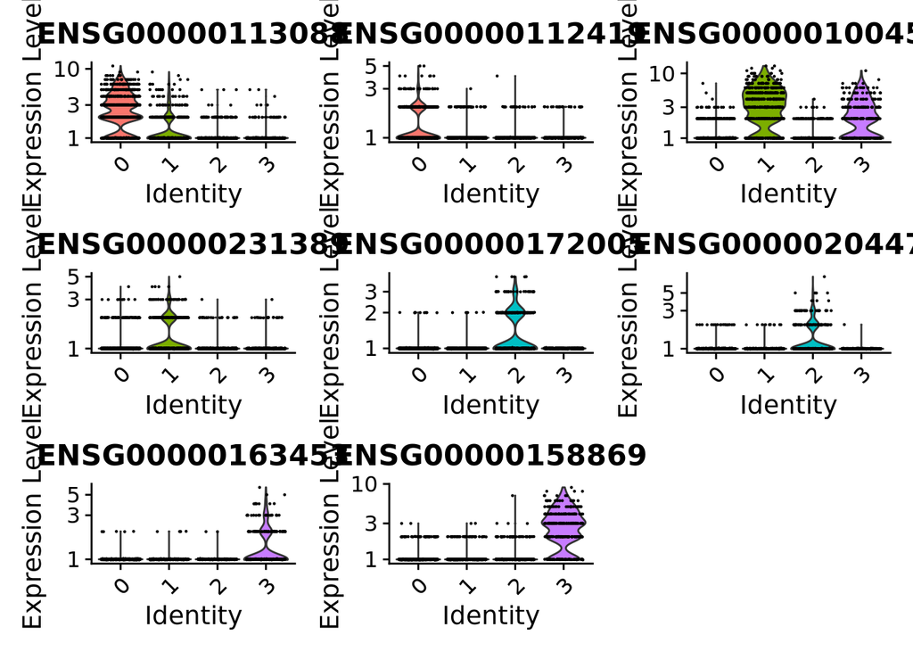

```r
# you can plot raw counts as well
VlnPlot(innateTcell, features = c("ENSG00000113088","ENSG00000112419","ENSG00000100450","ENSG00000231389",
"ENSG00000172005","ENSG00000204472","ENSG00000163453","ENSG00000158869"), layer = "counts", log = TRUE)
```

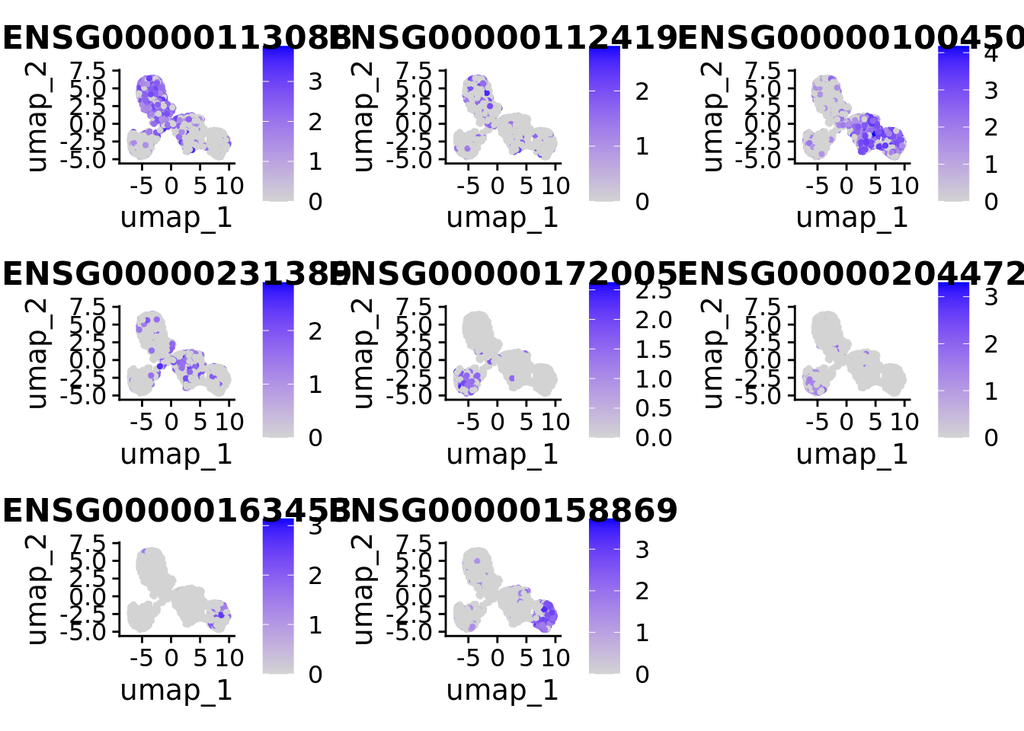

```r
FeaturePlot(innateTcell, features = c("ENSG00000113088","ENSG00000112419","ENSG00000100450","ENSG00000231389",
"ENSG00000172005","ENSG00000204472","ENSG00000163453","ENSG00000158869"))
```

```r
saveRDS(innateTcell, file = "../results/seurat_final.rds")
```